# Homework 3

Jaxon Lara

2024-10-01

# **Part1.**

## **1.**

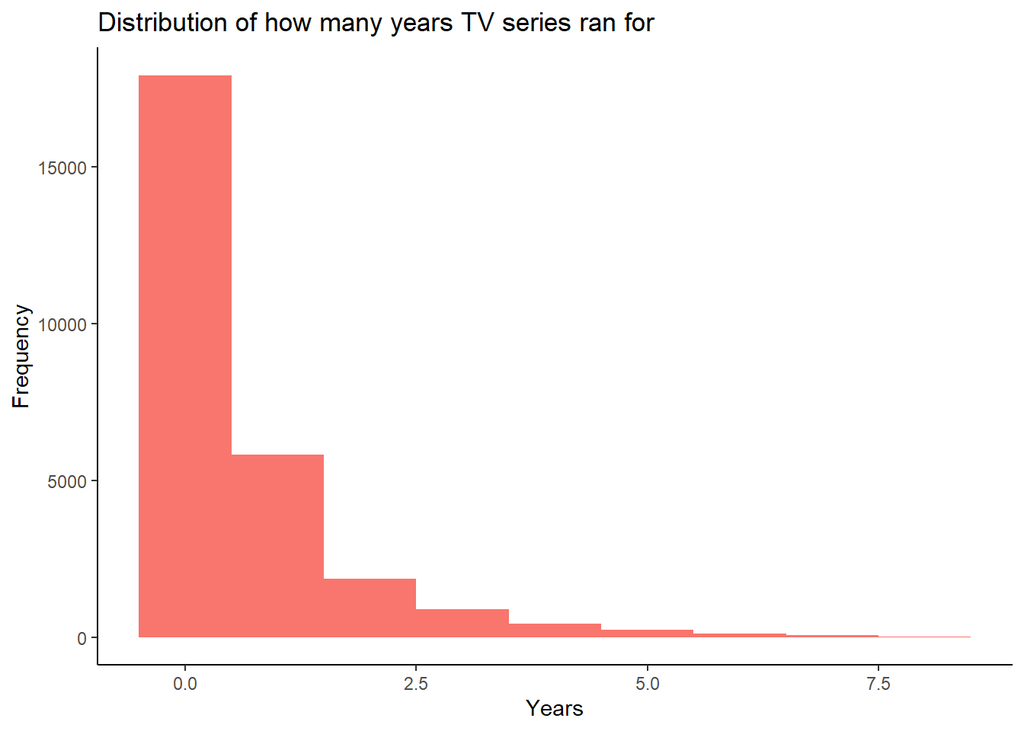

17919 TV series ended in the same year they started.

## **2.**

0.64% of TV series do not have rating information.

[output not shown]

## **3.**

# **Part2.**

## **4.**

I picked the albums dataset because I liked that it had a lot of numeric variables, it was also fairly clean with few NAs and it had a rounded number of rows. The context itself was interesting because I listen to a lot of music on Spotify myself though not necessarily any popular songs. I was mostly interested in seeing if there were any correlations with the Spotify popularity score. I chose predictors based on what I thought may show interestng relationships with the Spotify popularity score of an album. For example I thought combining the two variables “weeks on billboard” and “peak billboard position” would create an even better predictor variable. I also thought it would be interesting if the genres in an album can affect how popular it is since music tastes are subjective. I expected to see atleast a moderate relationship with the Spotify popularity score of an album although only the weighted billboards predictor did.

## **5.**

I had a lot of issues with getting rid of NA warnings and row deletion messages showing up in the html report. I did a bit of research to find what code works with ignoring NA in a graphing context and which worked in a calculation context. Then I had to figure out whether the code went inside the aes() or outside. After a bit of trial and error I managed to clear it all up. Next time I plan to have more written notes available for me to reference. Although I had been writing all the code I’ve learned in a separate .rmd file I had forgotten about ignoring or removing NA code. I learned that I can solve problems on my own through referencing online materials.

## **6.**

I prefer to listen to small artists and relatively unkown albums so to me I don’t have much of a reference on popular songs or what makes an album “good” according to professionals in the field or people who listen to a lot of popular music. So instead of analyzing the rankings as my output variable I was more interesting in analyzing Spotify popularity scores because I was interested in how songs are recommended to me and if rankings mattered to it. I also leaned more towards finding correlation instead of presenting something as having a negligible, for example there were some low r values around .2 which could be explained as very weak or negligible. Someone else may have decided to describe those correlation values as negligible relationship. Someone else may have also dicided to analyze a different output variable like the 2020 rankings. Instead analyzing rankings as the the variable spotify poplarity contributes to and not the other way around.